# simple_model_example

```python
import matplotlib.pyplot as plt
%matplotlib inline
import numpy as np
import pandas as pd
from sklearn.model_selection import train_test_split
from sklearn.metrics import roc_curve, classification_report, confusion_matrix, accuracy_score
from sklearn.ensemble import RandomForestClassifier
from sklearn.model_selection import train_test_split
from sklearn.model_selection import cross_val_score
from sklearn.model_selection import GridSearchCV

# import local packages
from qfml_workflow import dataStructures
from qfml_workflow import cusumFilter
from qfml_workflow import labeling
from qfml_workflow import multiprocess
```

### Read in data

```python
dbars_datapath = 'E:/Prado Research/qfml_workflow clean/qfml_workflow/data/interim/SPY_dollarbars.csv'
# raw data
#datapath = 'F:/prado research data/trades_short_condensed/SPY_trades_condensed.csv'


# Uncomment this line to create dollar bars from raw data file and save to csv
#dollar_bars = dataStructures.dollar_bars(datapath, 70000000, outfp='E:/Prado Research/qfml_workflow clean/qfml_workflow/data/interim/SPY_dollarbars.csv')
dollar_bars = pd.read_csv(dbars_datapath)
dollar_bars.info()
```

```
<class 'pandas.core.frame.DataFrame'>
RangeIndex: 416765 entries, 0 to 416764
Data columns (total 8 columns):
timestamp            416765 non-null float64
open                 416765 non-null float64
high                 416765 non-null float64
low                  416765 non-null float64
close                416765 non-null float64
volume               416765 non-null float64
tick_num             416765 non-null float64
num_ticks_sampled    416765 non-null float64
dtypes: float64(8)
memory usage: 25.4 MB
```

### Check for duplicate indicies

```python
# duplicates could be due to error in dollar bar creation
dollar_bars['timestamp'].duplicated(keep='first').sum()
```

```
19
```

Add a small offset to duplicate indicies to preserve data

```python
dollar_bars['timestamp'] = pd.to_datetime(dollar_bars['timestamp'])
duplicates = dollar_bars[dollar_bars.duplicated(subset='timestamp')]

for idx, duplicate in duplicates.iterrows():
    # add offset of 1 millisecond
    dollar_bars.at[idx, 'timestamp'] = duplicate['timestamp'] + pd.Timedelta(milliseconds=1)

# set timestamp as index
dollar_bars['timestamp'] = pd.to_datetime(dollar_bars['timestamp'], unit='ns')
dollar_bars.set_index('timestamp', drop=True, inplace=True)
```

```python
# check to make sure duplicates were removed
dollar_bars.index.duplicated(keep='first').sum()
```

```
0
```

### Create a Primary Model

This could be anything from an ML model to a simple rule-based strategy. For simplicity, let us use a basic rule-based technical analysis strategy, the simple moving average crossover.

- When fast moving average crosses over slow moving average, emit 1 for a long signal
- When fast moving average crosses under slow moving average, emit a -1 for a short signal.

```python
# make primary model
fast_window = 20
slow_window = 50

dollar_bars['fast_mavg'] = dollar_bars['close'].rolling(window=fast_window, min_periods=fast_window, center=False).mean()
dollar_bars['slow_mavg'] = dollar_bars['close'].rolling(window=slow_window, min_periods=slow_window, center=False).mean()

# Compute sides
dollar_bars['side'] = np.nan

long_signals = dollar_bars['fast_mavg'] >= dollar_bars['slow_mavg']
short_signals = dollar_bars['fast_mavg'] < dollar_bars['slow_mavg']
dollar_bars.loc[long_signals, 'side'] = 1
dollar_bars.loc[short_signals, 'side'] = -1

# lag the signal to remove look-ahead bias
dollar_bars['side'] = dollar_bars['side'].shift(1)
```

```python
# save a copy of the df for the secondary model
secondaryModelData = dollar_bars.copy()
# drop NaNs created by moving average lag
dollar_bars.dropna(axis=0, how='any', inplace=True)
```

### Sample significant events with CUSUM filter

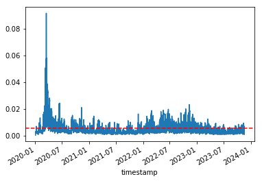

```python
# hyperparam here
dailyVol = cusumFilter.getDailyVol(dollar_bars['close'], span0=100)

f,ax=plt.subplots()
dailyVol.plot(ax=ax)
ax.axhline(dailyVol.mean(),ls='--',color='r')
```

```python
dollar_bars['close'].duplicated(keep='first').sum()
#dollar_bars.index.drop_duplicates(keep='first', inplace=True)
print(dollar_bars.index.duplicated(keep='first').sum())
dollar_bars = dollar_bars[~dollar_bars.index.duplicated(keep='first')]
```

```
0
```

CUSUM essentially samples an event every time an underlying series crosses a threshold h

```python
# tEvents are the CUSUM Filter events
# CUSUM essentially samples an event every time an underlying series
# crosses a threshold h
cusumEvents = cusumFilter.getTEvents(dollar_bars['close'],h=dailyVol.mean())
```

### Get vertical barriers based on CUSUM events

```python
vertical_barriers = labeling.addVerticalBarrier(cusumEvents, dollar_bars['close'], numDays=1)
```

### Label observations using triple barrier method

- triple barrier method uses two horizontal barriers (profit taking and stop loss) along with a vertical barrier (time expiry) to create labels.

```python
# multiply horizontal profit taking barrier by 1 and stop loss barrier by 2
pt_sl = [1, 2]

# minimum return
min_ret = 0.005


# indexes that arent being found are indexes where dailyVol was creating
# the ema, and therefore are nan. Two possible solutions:
# 1. Backfill data into Nan columns
# 2. Drop Nan columns
# best solution is likely to leave as Nan, Nan values will not be considered
# in getEvents method.
dailyVol = dailyVol.reindex(cusumEvents)

# apply triple barrier labeling, throws error in newer pandas versions
tripleBarrierEvents = labeling.getEvents(close=dollar_bars['close'],
                                               tEvents=cusumEvents,
                                               ptSl=pt_sl,
                                               trgt=dailyVol,
                                               minRet=min_ret,
                                               numThreads=3,
                                               t1=vertical_barriers, # vertical barrier times
                                               side=dollar_bars['side']) # side prediction
```

```
2023-11-30 13:09:27.409014 100.0% applyPtSlOnT1 done after 0.33 minutes. Remaining 0.0 minutes..
```

```python
# get labels
labels = labeling.getBins(tripleBarrierEvents, dollar_bars['close'])
#print(labels.info())
print(labels.bin.value_counts())
```

```
1.0    10429
0.0     6594
Name: bin, dtype: int64
```

### Evaluate primary model

```python
primaryForecast = pd.DataFrame(labels['bin'])
primaryForecast['pred'] = 1
primaryForecast.columns = ['actual', 'pred']

# Performance Metrics
actual = primaryForecast['actual']
pred = primaryForecast['pred']
print(classification_report(y_true=actual, y_pred=pred))

print("Confusion Matrix")
print(confusion_matrix(actual, pred))

print('')
print("Accuracy")
print(accuracy_score(actual, pred))
```

```
              precision    recall  f1-score   support

         0.0       0.00      0.00      0.00      6594
         1.0       0.61      1.00      0.76     10429

   micro avg       0.61      0.61      0.61     17023
   macro avg       0.31      0.50      0.38     17023
weighted avg       0.38      0.61      0.47     17023

Confusion Matrix
[[    0  6594]
 [    0 10429]]

Accuracy
0.6126417200258474
```

### Create a secondary Meta-Model to determine the side of each bet

(WIP) Create advanced features according to AFML implementation

```python
# Compute features
# Log Returns
secondaryModelData['log_ret'] = np.log(secondaryModelData['close']).diff()

# Momentum
secondaryModelData['mom1'] = secondaryModelData['close'].pct_change(periods=1)
secondaryModelData['mom2'] = secondaryModelData['close'].pct_change(periods=2)
secondaryModelData['mom3'] = secondaryModelData['close'].pct_change(periods=3)
secondaryModelData['mom4'] = secondaryModelData['close'].pct_change(periods=4)
secondaryModelData['mom5'] = secondaryModelData['close'].pct_change(periods=5)

# Volatility
secondaryModelData['volatility_50'] = secondaryModelData['log_ret'].rolling(window=50, min_periods=50, center=False).std()
secondaryModelData['volatility_25'] = secondaryModelData['log_ret'].rolling(window=25, min_periods=25, center=False).std()
secondaryModelData['volatility_10'] = secondaryModelData['log_ret'].rolling(window=10, min_periods=10, center=False).std()

# Serial Correlation (Takes about 4 minutes)
window_autocorr = 50

# Runs too long for larger datasets
#secondaryModelData['autocorr_1'] = secondaryModelData['log_ret'].rolling(window=window_autocorr, min_periods=window_autocorr, center=False).apply(lambda x: x.autocorr(lag=1), raw=False)
#secondaryModelData['autocorr_2'] = secondaryModelData['log_ret'].rolling(window=window_autocorr, min_periods=window_autocorr, center=False).apply(lambda x: x.autocorr(lag=2), raw=False)
#secondaryModelData['autocorr_3'] = secondaryModelData['log_ret'].rolling(window=window_autocorr, min_periods=window_autocorr, center=False).apply(lambda x: x.autocorr(lag=3), raw=False)
#secondaryModelData['autocorr_4'] = secondaryModelData['log_ret'].rolling(window=window_autocorr, min_periods=window_autocorr, center=False).apply(lambda x: x.autocorr(lag=4), raw=False)
#secondaryModelData['autocorr_5'] = secondaryModelData['log_ret'].rolling(window=window_autocorr, min_periods=window_autocorr, center=False).apply(lambda x: x.autocorr(lag=5), raw=False)

# Get the various log -t returns
secondaryModelData['log_t1'] = secondaryModelData['log_ret'].shift(1)
secondaryModelData['log_t2'] = secondaryModelData['log_ret'].shift(2)
secondaryModelData['log_t3'] = secondaryModelData['log_ret'].shift(3)
secondaryModelData['log_t4'] = secondaryModelData['log_ret'].shift(4)
secondaryModelData['log_t5'] = secondaryModelData['log_ret'].shift(5)
```

```python
# re-compute the sides
secondaryModelData['side'] = np.nan

long_signals = secondaryModelData['fast_mavg'] >= secondaryModelData['slow_mavg']
short_signals = secondaryModelData['fast_mavg'] < secondaryModelData['slow_mavg']

secondaryModelData.loc[long_signals, 'side'] = 1
secondaryModelData.loc[short_signals, 'side'] = -1
```

```python
# Get features at event dates
X = secondaryModelData.loc[labels.index, :]

# Drop unwanted columns
X.drop(['open', 'high', 'low', 'close', 'tick_num', 'num_ticks_sampled','fast_mavg', 'slow_mavg',], axis=1, inplace=True)

y = labels['bin']
```

```python
y.value_counts()
```

```
1.0    10429
0.0     6594
Name: bin, dtype: int64
```

The classes are imbalanced, which is solved in the Sample Weights section of the workflow

### Create train-test split

```python
# create training data
X_train, X_test, y_train, y_test = train_test_split(X, y, test_size=0.15, shuffle=False)
#train_df = pd.concat([y_train, X_train], axis=1, join='inner')
#y_train = train_df['bin']
#X_train= train_df.loc[:, train_df.columns != 'bin']
```

```python
# Create training data
#y_train = train_df['bin']
#X_train= train_df.loc[:, train_df.columns != 'bin']
```

### Create and fit a random forest model to determine side (Meta Labeling)

- Later in the development process, a more robust CV method will be use that takes into account overlapping labels but still WIP

```python
parameters = {'max_depth':[2, 3, 4, 5, 7],
              'n_estimators':[1, 10, 25, 50, 100, 256, 512],
              'random_state':[12]}

def perform_grid_search(X_data, y_data):
    rf = RandomForestClassifier(criterion='entropy')

    # This should be custom CV from CV section
    clf = GridSearchCV(rf, parameters, cv=4, scoring='roc_auc', n_jobs=3)

    clf.fit(X_data, y_data)

    print(clf.cv_results_['mean_test_score'])

    return clf.best_params_['n_estimators'], clf.best_params_['max_depth']
```

```python
# get params
n_estimator, depth = perform_grid_search(X_train, y_train)
c_random_state = 12
print(n_estimator, depth, c_random_state)
```

```
[0.51330636 0.53311463 0.61008394 0.65751086 0.69540946 0.70007415
 0.70052563 0.52841758 0.61551339 0.71520149 0.73762013 0.74808146
 0.73904111 0.74124426 0.58846954 0.6738066  0.73679518 0.75936394
 0.76954135 0.76365955 0.7633477  0.55308484 0.71842951 0.75025015
 0.78541001 0.79330538 0.7941184  0.79498515 0.65555647 0.77187774
 0.80141077 0.81369018 0.82254425 0.82474272 0.82405023]
256 7 12
```

```python
# Refit a new model with best params, so we can see feature importance
rf = RandomForestClassifier(max_depth=depth, n_estimators=n_estimator,
                            criterion='entropy', random_state=c_random_state)

rf.fit(X_train, y_train.values.ravel())
```

```
RandomForestClassifier(bootstrap=True, class_weight=None, criterion='entropy',
            max_depth=7, max_features='auto', max_leaf_nodes=None,
            min_impurity_decrease=0.0, min_impurity_split=None,
            min_samples_leaf=1, min_samples_split=2,
            min_weight_fraction_leaf=0.0, n_estimators=256, n_jobs=None,
            oob_score=False, random_state=12, verbose=0, warm_start=False)
```

### Training Statistics

```
              precision    recall  f1-score   support

         0.0       0.80      0.65      0.72      5615
         1.0       0.80      0.90      0.85      8854

   micro avg       0.80      0.80      0.80     14469
   macro avg       0.80      0.77      0.78     14469
weighted avg       0.80      0.80      0.80     14469

Confusion Matrix
[[3653 1962]
 [ 912 7942]]

Accuracy
0.8013684428778768
```

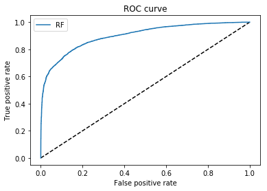

```python
# Performance Metrics
y_pred_rf = rf.predict_proba(X_train)[:, 1]
y_pred = rf.predict(X_train)
fpr_rf, tpr_rf, _ = roc_curve(y_train, y_pred_rf)
print(classification_report(y_train, y_pred))

print("Confusion Matrix")
print(confusion_matrix(y_train, y_pred))

print('')
print("Accuracy")
print(accuracy_score(y_train, y_pred))

plt.figure(1)
plt.plot([0, 1], [0, 1], 'k--')
plt.plot(fpr_rf, tpr_rf, label='RF')
plt.xlabel('False positive rate')
plt.ylabel('True positive rate')
plt.title('ROC curve')
plt.legend(loc='best')
plt.show()
```

### Testing Statistics

```
              precision    recall  f1-score   support

         0.0       0.78      0.58      0.67       979
         1.0       0.78      0.90      0.83      1575

   micro avg       0.78      0.78      0.78      2554
   macro avg       0.78      0.74      0.75      2554
weighted avg       0.78      0.78      0.77      2554

Confusion Matrix
[[ 569  410]
 [ 162 1413]]

Accuracy
0.7760375880971025
```

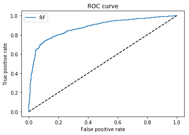

```python
# Meta-label
# Performance Metrics
y_pred_rf = rf.predict_proba(X_test)[:, 1]
y_pred = rf.predict(X_test)
fpr_rf, tpr_rf, _ = roc_curve(y_test, y_pred_rf)
print(classification_report(y_test, y_pred))

print("Confusion Matrix")
print(confusion_matrix(y_test, y_pred))

print('')
print("Accuracy")
print(accuracy_score(y_test, y_pred))

plt.figure(1)
plt.plot([0, 1], [0, 1], 'k--')
plt.plot(fpr_rf, tpr_rf, label='RF')
plt.xlabel('False positive rate')
plt.ylabel('True positive rate')
plt.title('ROC curve')
plt.legend(loc='best')
plt.show()
```

### Primary model performance on test set without Meta Labeling

```python
# Primary model
primary_forecast = pd.DataFrame(labels['bin'])
primary_forecast['pred'] = 1
primary_forecast.columns = ['actual', 'pred']

#start = primary_forecast.index.get_loc('2016-01-20 14:42:03.869000')
#end = primary_forecast.index.get_loc('2017-12-04 15:45:10.747000') + 1
start = primary_forecast.index.get_loc(X_test.index[0])
end = primary_forecast.index.get_loc(X_test.index[-1])

subset_prim = primary_forecast[start:end]

# Performance Metrics
actual = subset_prim['actual']
pred = subset_prim['pred']
print(classification_report(y_true=actual, y_pred=pred))

print("Confusion Matrix")
print(confusion_matrix(actual, pred))

print('')
print("Accuracy")
print(accuracy_score(actual, pred))
```

```
              precision    recall  f1-score   support

         0.0       0.00      0.00      0.00       978
         1.0       0.62      1.00      0.76      1575

   micro avg       0.62      0.62      0.62      2553
   macro avg       0.31      0.50      0.38      2553
weighted avg       0.38      0.62      0.47      2553

Confusion Matrix
[[   0  978]
 [   0 1575]]

Accuracy
0.6169212690951822
```

### Simple feature importance

Later in the implementation, a more robust feature importance method will be used, but for this stage the basic sklearn feature importance is used (WIP)

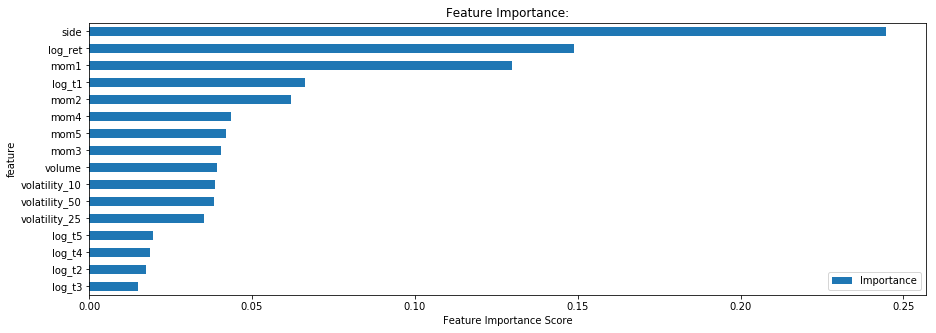

```python
# Feature Importance
title = 'Feature Importance:'
figsize = (15, 5)

feat_imp = pd.DataFrame({'Importance':rf.feature_importances_})
feat_imp['feature'] = X.columns
feat_imp.sort_values(by='Importance', ascending=False, inplace=True)
feat_imp = feat_imp

feat_imp.sort_values(by='Importance', inplace=True)
feat_imp = feat_imp.set_index('feature', drop=True)
feat_imp.plot.barh(title=title, figsize=figsize)
plt.xlabel('Feature Importance Score')
plt.show()
```